# AMEN tutorial

Juan Tellez

2/27/2020

# Introduction

This tutorial walks you through using the `AMEN` package with data on interstate conflict (MIDs) from Reiter and Stam (2003).

```r
library(tidyverse)
library(haven)
```

Let’s load the data below and look at it.

```r
## read data and add variables
data = read_dta('/Users/dorffc/Dropbox/Research/nothingbutnet/netsMatter/replications/Reiter_Stam_2003/input/doublereduce.dta')
#data = read_dta('/Users/JuamnTellez/Dropbox/papers/netsMatter/replications/Reiter_Stam_2003/input/doublereduce.dta')
```

For this tutorial, we only want the subset of the variables that were in the original analysis, and then we want to drop missing observations.

```r
## get variables needed
base_vars = c('sideaa', "pdemdtar", "pdemdin", "personal", "military",
              "single", "democ", "contig", "majpow", "ally", "loglsrat",
              "advanced", "dispyrs", "dspline1", "dspline2", "dspline3",
              "statea", "stateb", "year")

## subset the data by variables needed and years
dataComp = na.omit(data[, base_vars])
```

# Formatting the Data

Using the AMEN function requires formatting data into a particular structure. The primary distinction in data formatting is whether the outcome of interest represents a directed or undirected network.

## Helper Functions

We provide some helper functions to make formatting easier.

First we need a *vector* of the years in the dataset, and then a *list* that tells us, *for each year*, which countries are present in the data (here represented by COW codes).

```r
yrs = sort(unique(dataComp$year))
cntriesT = lapply(yrs, function(t){ as.character( unique( dataComp$statea[dataComp$year==t] ) ) })
```

### Format Y (The Outcome)

```r
## format dependent variable
yVar = 'sideaa' # name of outcome in dataset
yList = lapply(1:length(yrs), function(ii){
  slice = data[ which(
    data$year==yrs[ii] &
      data$statea %in% cntriesT[[ii]] &
      data$stateb %in% cntriesT[[ii]]
  ), c('statea', 'stateb', yVar) ]
  adj = reshape2::acast(slice, statea ~ stateb, value.var=yVar)
  return( adj[ cntriesT[[ii]], cntriesT[[ii]] ] )
})
```

Here’s an example of one year of data (only 5 countries shown for space purposes):

```r
yList[[1]][1:5, 1:5]
```

```
##    20  2 40 41 42
## 20 NA  0  0  0  0
## 2   0 NA  0  0  0
## 40  0  0 NA  0  0
## 41  0  0  0 NA  0
## 42  0  0  0  0 NA
```

### Format Xdyad, the Dyadic Covariates

Now we will format `Xdyad` from above, which includes the dyadic covariates. `Xdyad` is a $T$ length of $n\times n\times p$ arrays, where $p$ = number of dyadic covariates in dataset.

Roughly, the code below does the following: for each year in the dataset, subset down to the countries present in that year and all of the dyadic variables in `dyad_vars`; then cast the data into an array that is $n\times n\times p$, before storing it into the list.

```r
# get dyadic variables
dyad_vars = c('personal', 'military', 'single', 'democ', 'contig',
              'ally', 'majpow', 'loglsrat', 'advanced',
              'dispyrs', 'dspline1', 'dspline2', 'dspline3',
              'pdemdtar', 'pdemdin')

## format dyadic covariates
xDyadList = lapply(1:length(yrs), function(ii){
  slice = data[ which(
    data$year==yrs[ii] &
      data$statea %in% cntriesT[[ii]] &
      data$stateb %in% cntriesT[[ii]]
  ), c('statea', 'stateb', dyad_vars) ]
  sliceL = reshape2::melt(slice, id=c('statea','stateb'))
  adj = reshape2::acast(sliceL, statea ~ stateb ~ variable, value.var='value')
  return( adj[ cntriesT[[ii]], cntriesT[[ii]],  ] )
})
```

Here’s an example of what the first year of data looks like for the first covariate, named `personal` (only 5 countries shown for space purposes):

```r
xDyadList[[1]][1:5,1:5,1]
```

```
##    20  2 40 41 42
## 20 NA  0  0  0  0
## 2   0 NA  0  0  0
## 40  0  0 NA  0  0
## 41  0  0  0 NA  0
## 42  0  0  0  0 NA
```

We are done formatting the data and are ready for fitting the model.

# Running AMEN

There is often little theoretical reason to choose a particular value of $\sf{R}$ (above). One strategy is to estimate models at different values of $\sf{R}$ and compare goodness of fit statistics across models.

Given the computational intensity needed for parameter estimates to converge, parallelization strategies are recommended to speed up analysis. In addition, providing AMEN function with starting values, either dictated by theory, previous research, or previous runs can also help speed up convergence time.

Below, we load the library, and in `resultsPath` we set a path to store results.

```r
## load most updated amen package
devtools::install_github('s7minhas/amen') ; library(amen)

## Run amen in parallel
library(doParallel) ; library(foreach)

## setup result output directory
#resultsPath = '/Users/JuamnTellez/Dropbox/papers/netsMatter/replications/Reiter_Stam_2003/output/'
resultsPath = '/Users/dorffc/Dropbox/Research/nothingbutnet/netsMatter/replications/Reiter_Stam_2003/output/'
```

```r
## running in parallel varying k
imps = 10000  # number of interations in MCMC
brn =  2500   # number of burn-in
ods = 1 # thinning parameter
## (1 is suggested unless there is some evidence of autocorrelation in the chain)
latDims = 0:3 # dimension of latent space (search up to 3 dimension  is suggested)
seed=6886 # set your model seed
```

Now we run the model, in parallel. We fit a separate model for each element in `latDims` (so a model with a zero dimensional latent space, 1 dimensional latent space, etc.).

The key function here is `ame_repL` which fits the model. We wrap the whole function in a `foreach` call so we can run separate models for each element in `latDims`.

```r
## select number of cores to locate
cl=makeCluster(6) ; registerDoParallel(cl) # number of clusters depends
## on how many cores your computer or cluster has

foreach(ii=1:length(latDims), .packages=c("amen")) %dopar% {

  ameFit = ame_repL(
    Y=yList,Xdyad=xDyadList,
    Xrow=NULL,Xcol=NULL,
    model="bin",symmetric=FALSE,intercept=TRUE,R=latDims[ii],
    nscan=imps, seed=seed, burn=brn, odens=ods,
    plot=FALSE, print=FALSE, gof=TRUE,
    periodicSave=TRUE)

  save(ameFit, file=paste0(resultsPath, 'model_k', latDims[ii],'_v1.rda') )
  # save the output of your data
}

## terminate parallel sockets
stopCluster(cl)
```

In cases when the model fails to converge you may want to run the model again or with a longer chain. In this case, it is often useful to set starting values which can help with convergence issues.

Below, we demonstrate how to take starting values from a prior run and then fit the model again.

```r
## load resuls from previous model run if needed
prevModelFiles = paste0(resultsPath, 'model_k', latDims,'_v1.rda')




## select number of cores to locate
cl=makeCluster(4) ; registerDoParallel(cl)

foreach(ii=1:length(latDims), .packages=c("amen")) %dopar% {

  load(prevModelFiles[ii]) # load previous model run

  startVals0 = ameFit$'startVals' # extract start vals

  rm(ameFit)  # dump the rest of the model run

  ameFit = ame_repL(
    Y=yList,Xdyad=xDyadList,
    Xrow=NULL,Xcol=NULL,
    model="bin",symmetric=FALSE,intercept=TRUE,R=latDims[ii],
    nscan=imps, seed=seed, burn=brn, odens=ods,
    plot=FALSE, print=FALSE, gof=TRUE, startVals=startVals0,
    periodicSave=TRUE)

  # save the output of your data
  save(ameFit, file=paste0(resultsPath, 'model_k', latDims[ii],'_v2.rda') )
}

## terminate parallel sockets
stopCluster(cl)
```

# Posterior Analysis

Once we are satisfied that the model has converged, we can do posterior analysis to examine our parameter estimates. Below we load the results from the `AMEN` run. Simplicity, we only load results from $R = 0$.

```r
## load model fits from 0 to 3 dimensions
load( paste0(resultsPath,'model_k0_v12.rda') ) ; ameFit_k0=ameFit
# load( paste0(resultsPath,'model_k1_v12.rda') ) ; ameFit_k1=ameFit
# load( paste0(resultsPath,'model_k2_v12.rda') ) ; ameFit_k2=ameFit
# load( paste0(resultsPath,'model_k3_v12.rda') ) ; ameFit_k3=ameFit
```

We can look at goodness of fit (GOF) statistics with the following:

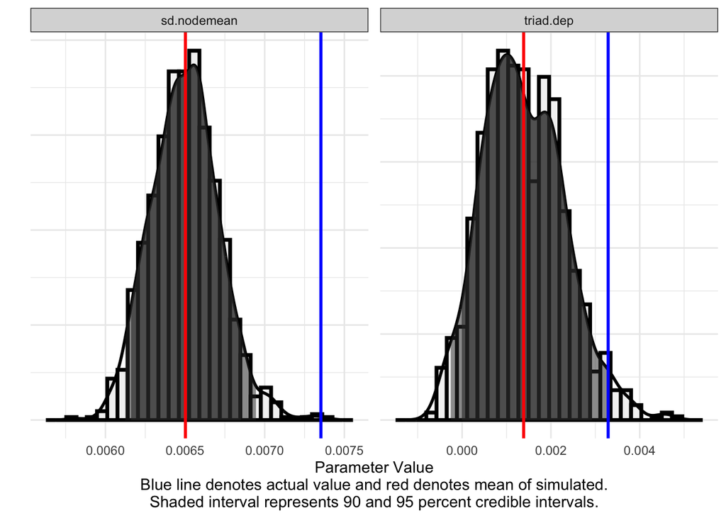

```r
## check out goodness of fit stats in posterior estimate for each dimension
amen::gofPlot(ameFit_k0$GOF, symmetric = TRUE)
```

```r
## check out beta parameters (posterior estimates for coefficients)
## and convergence for each dimension
summStats = function(x){
  # credible intervals
  res=c(mu=mean(x),med=median(x),sd=sd(x),quantile(x,probs=c(0.025,0.05,0.95,0.975)))
  round(res, 3)
}
apply(ameFit_k0$BETA, 2, summStats) %>% t()
```

```
##                   mu    med    sd   2.5%     5%    95%  97.5%
## intercept     -2.803 -2.803 0.056 -2.912 -2.898 -2.712 -2.696
## personal.dyad  0.202  0.200 0.090  0.029  0.058  0.350  0.365
## military.dyad -0.012 -0.002 0.216 -0.513 -0.392  0.323  0.359
## single.dyad   -0.200 -0.199 0.056 -0.303 -0.290 -0.107 -0.085
## democ.dyad    -0.463 -0.463 0.049 -0.555 -0.540 -0.385 -0.371
## contig.dyad    1.198  1.197 0.027  1.148  1.156  1.244  1.254
## ally.dyad      0.022  0.021 0.035 -0.042 -0.032  0.084  0.091
## majpow.dyad    0.502  0.506 0.073  0.336  0.378  0.616  0.628
## loglsrat.dyad -0.101 -0.101 0.008 -0.116 -0.114 -0.088 -0.086
## advanced.dyad  0.066  0.064 0.054 -0.031 -0.019  0.159  0.176
## dispyrs.dyad  -0.136 -0.136 0.007 -0.151 -0.149 -0.125 -0.123
## dspline1.dyad -0.001 -0.001 0.000 -0.002 -0.002 -0.001 -0.001
## dspline2.dyad  0.001  0.001 0.000  0.001  0.001  0.001  0.001
## dspline3.dyad  0.000  0.000 0.000  0.000  0.000  0.000  0.000
## pdemdtar.dyad  0.239  0.237 0.056  0.131  0.150  0.334  0.349
## pdemdin.dyad   0.125  0.129 0.061  0.000  0.017  0.215  0.231
```

```r
betaIndices<-split(1:ncol(ameFit_k0$BETA), ceiling(seq_along(1:ncol(ameFit_k0$BETA))/5))
```

And finally make plots to assess the converge of parameters:

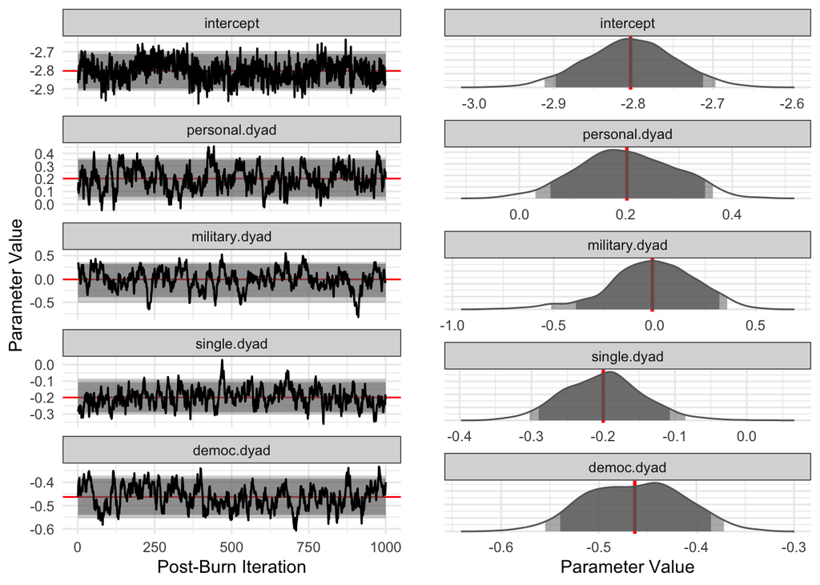

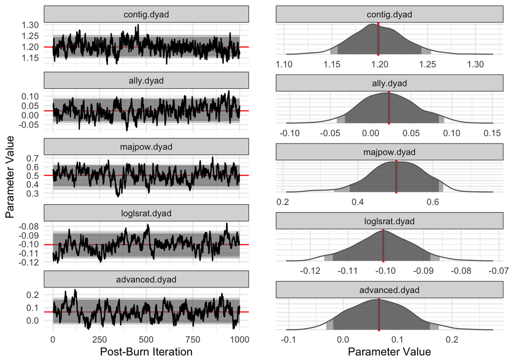

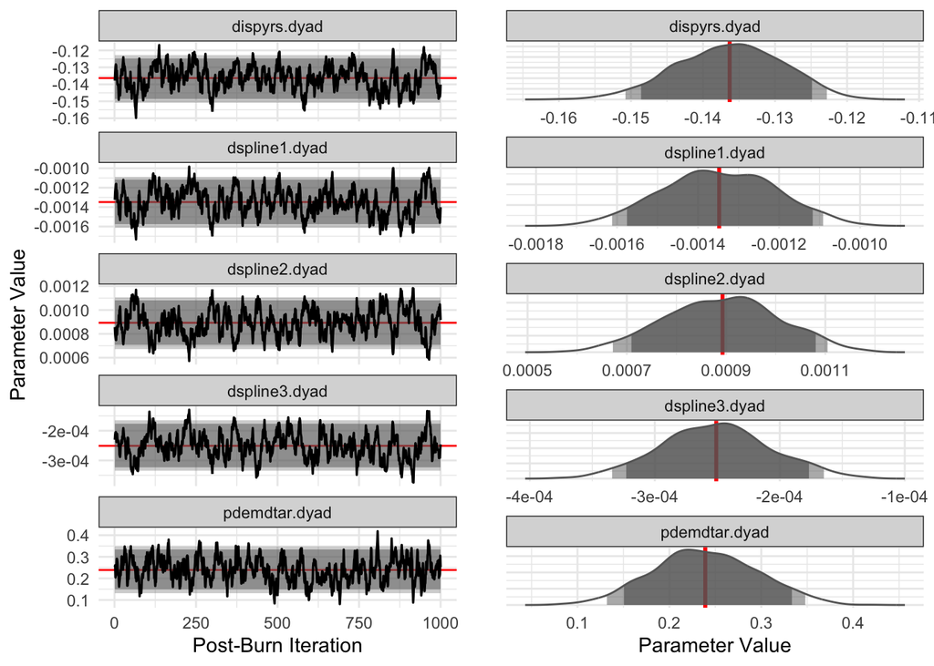

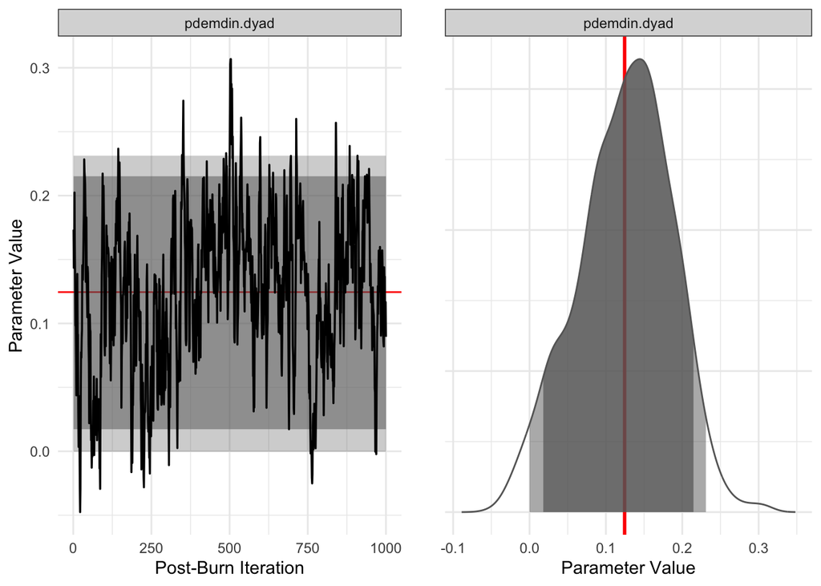

```r
## plot the parameters convergence using dimension k=0
for(bIndex in betaIndices){ amen::paramPlot( ameFit_k0$BETA[,bIndex,drop=FALSE] ) }
```

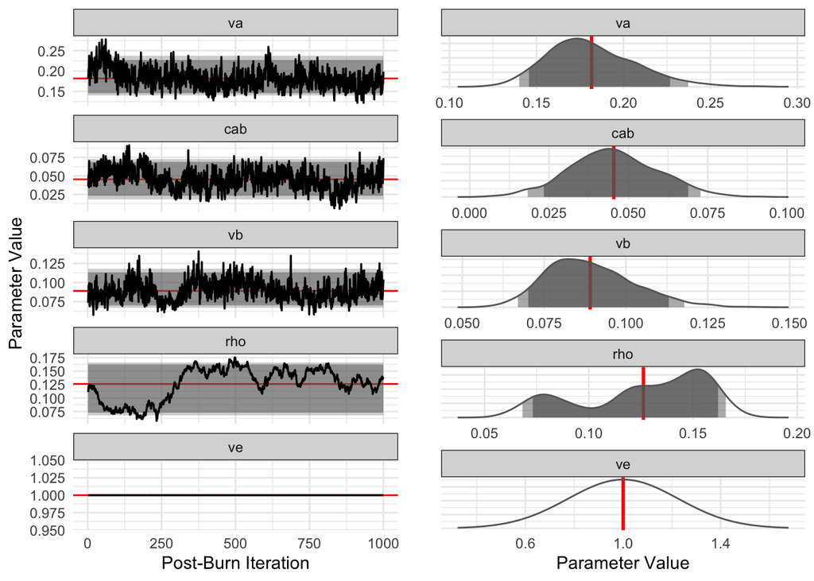

```r
amen::paramPlot(ameFit_k0$VC)
```